# Lab 0 (Week 2)

Students should be required to spend ~an hour of their own time to work through this tutorial before coming to the first/second discussion, so they can actively ask questions and engage in class.

# 0. Hello World

Official Python 3 tutorial: https://docs.python.org/3/tutorial/

Jupyter Notebook provides an interactive Python session, where you can run your code progressively, cell by cell. The run-time state, meaning all variable values, function definitions, etc., is automatically saved after you run each cell in a session.

Click on the play button on the cell below to execute its content. The stdout content (whatever you "print()") will be displayed belowed the cell

```python
print("Hello BIOE 488 students!")
```

```
Hello BIOE 488 students!
```

Now, imagine you have a variable

```
department = 'BIOE'
course_id = 488
```

**Task:** How can you achieve the same print line above using F-strings?

Try on the cell below...

**See solution**

```
department = 'BIOE'
course_id = 488
print(f' Hello {department} {course_id} students!')
```

```python
# Copy here the solution and check
department = 'BIOE'
course_id = 488
print(f"Hello {department} {course_id} students!")
```

```
Hello BIOE 488 students!
```

# 1. Basic Arithmetics in Python

Equal sign "=" in Python as well as most other programming languages means to assign a value to a variable. Python interpreter assigns the value on the right hand side (rhs) of "=" to the variable on the left hand side (lhs) of it. In the example below, the first line "a = 2" assigns variable "a" the numerical value 2

If rhs consists of arithmetic operations, logic operations, function calls or other calculations, Python interpreter cauculates the result before assigning it to the lhs.

Explore the calculations below to find out the usage of each operator.

```python
a = 2
b = 3
c = a + b
j = a * b
d = b ** a
e = 10
f = e / b
g = e // b
h = g - a
i = (50 - 5*6) / 4
p = 17 % 3

print(a, b, c, d, e, f, g, h, i)
```

```
2 3 5 9 10 3.3333333333333335 3 1 5.0
```

The expression on RHS must only contain variables/functions/names that are already defined. The cell below will generate an "undefined name" error.

```python
t = one + 2
```

```
---------------------------------------------------------------------------
NameError                                 Traceback (most recent call last)
Cell In[7], line 1
----> 1 t = one + 2

NameError: name 'one' is not defined
```

Because "=" is "assignment operator, statements like "a = a + 1" is totally valid in Python. It computes the result of the RHS expression "a + 1" and then assigns it back to LHS variable "a". What should the result be?

Such arithmetic operations can often be abbreviated as

+=

-=

*=

/=

...

See examples below.

```python
a = a + 1
print(a)
a += 1
print(a)
a *= 2
print(a)
a /= 2
print(a)
```

```
3
4
8
4.0
```

# 1.75 Data structures and Variables

Every variable has a data type. Use the built-in "type()" function to find out the type of a variable like below:

```python
a = 3.2
print(a, type(a))
b = -2
print(b, type(b))
c = "hello"
print(c, type(c))
```

```
3.2 <class 'float'>
-2 <class 'int'>
hello <class 'str'>
```

Python 3 allows arithmetic operations between different datatypes.

```python
d = a * b
print(d, type(d))
```

```
-6.4 <class 'float'>
```

Lists are mutable objects. Explore the common list operations below:

```python
my_color = "red"

# creating lists
list_a = [1, 2, "Adam", my_color, "banana"]
list_b = [0, list_a]
list_c = []
```

```python
print(list_a)
print(list_b)
print(list_c)
```

```
[1, 2, 'Adam', 'red', 'banana']
[0, [1, 2, 'Adam', 'red', 'banana']]
[]
```

```python
# appending new element to list
list_b.append("new element")
print(list_b)

# insert to arbitrary location in a list (change 0 to a different index?)
list_b.insert(0, "another element")
print(list_b)

# check if element exists in list
print(0 in list_b)
print(9 in list_b)
```

```
[0, [1, 2, 'Adam', 'red', 'banana'], 'new element']
['another element', 0, [1, 2, 'Adam', 'red', 'banana'], 'new element']
True
False
```

```python
# iterate over all elements in a list
for item in list_a:
  print(item)

# select a section of a list, described by the starting and ending indicies
for item in list_a[1:3]:
  list_c.append(item)

print(list_c)
```

```
1
2
Adam
red
banana
[2, 'Adam']
```

In the cell below, list_0 and list_1 are two **references** of the same list. When you modify the underlying list through either reference, both references will be affected.

```python
list_0 = [0, 1, 2, 3]
list_1 = list_0

print(list_0)
print(list_1)

list_0.append(5)

print(list_0)
print(list_1)
```

```
[0, 1, 2, 3]
[0, 1, 2, 3]
[0, 1, 2, 3, 5]
[0, 1, 2, 3, 5]
```

### Dictionaries

Dictionaries are key-value containers that provides **fast** look-up by key. Explore the common dictionary operations below:

```python
# creating a dictionary
phonebook = {"Adam": 321654987, "Bob": 789456123, "Charlie": 147258369}
print(len(phonebook))
print(phonebook)

# looking up a key
print(phonebook["Adam"])

my_name = "Azis"
my_number = 111111111

# creating a new entry with variables
phonebook[my_name] = my_number
phonebook[0] = 1

# deleting an entry
del phonebook["Adam"]

print(phonebook)

# iterate over all entries
for name, number in phonebook.items():
  print("The phone number of {} is {}".format(name, number))

# check if key exists in dictionary
if "Bob" in phonebook:
  print("Bob is in the phonebook")

# modifying the value of a key
phonebook["Charlie"] = 1


print(phonebook)
```

```
3
{'Adam': 321654987, 'Bob': 789456123, 'Charlie': 147258369}
321654987
{'Bob': 789456123, 'Charlie': 147258369, 'Azis': 111111111, 0: 1}
The phone number of Bob is 789456123
The phone number of Charlie is 147258369
The phone number of Azis is 111111111
The phone number of 0 is 1
Bob is in the phonebook
{'Bob': 789456123, 'Charlie': 1, 'Azis': 111111111, 0: 1}
```

**Task:** Create a dictionary named book with the following keys: `title`, `author`, and `year_published`.

Use the cell below

**See solution**

```
book = {
    "title": "To Kill a Mockingbird",
    "author": "Harper Lee",
    "year_published": 1960
}
print(book)
```

```python
# Use this cell

book = {"title":'NA', 'author':'NA', 'year_published':'NA'}
book
```

```
{'title': 'NA', 'author': 'NA', 'year_published': 'NA'}
```

**Task:** Using the book dictionary you created earlier, change the `year_published` to 1961 and add a new key-value pair: `genre` with a value of "Fiction".

Use the cell below

```python
# Modify the dictionary

book['year_published'] = 1961
book['genre'] = "Fiction"

book
```

```
{'title': 'NA', 'author': 'NA', 'year_published': 1961, 'genre': 'Fiction'}
```

# 1.5. Control Flow Statements

The interpreter normally executes code line by line, however, we can use control flow statements to manage the control flow.

for, while and if statements

Logic break, continue, else elif range() function

- Indentations in Python

For loops

a "for" loop repeats execution of the code in its scope over the items of a given sequence.

```python
fruits = ["apples", "oranges", "bananas"]
for fruit in fruits:
  print("I love eating {}".format(fruit))
```

```
I love eating apples
I love eating oranges
I love eating bananas
```

**continue** statement skips the execution to the next iteration in a loop. See the cell below for example

```python
my_color = "red"

# creating lists
list_a = [1, 2, "Adam", my_color, 3, "banana", 5]

for element in list_a:
  if type(element) == type(" "):
    continue
  print(element)
```

```
1
2
3
5
```

**break** terminates the execution of a loop and skip out of the loop

```python
my_color = "red"

# creating lists
list_a = [1, 2, "Adam", my_color, 3, "banana", 5]
for element in list_a:
  print(element)
  if type(element) == type(" "):
    break
  print(element)
```

```
1
1
2
2
Adam
```

```python
## Example
for i in range(5):
  print(i)
## Reverse
print('')
for j in range(10, 0, -2):
  print(j)
```

```
0
1
2
3
4

10
8
6
4
2
```

**Task**: Given the dictionary, print the each student name and their pass/fail in the following format (example): The criteria for pass/failed is 50%. Bonus: update the dictionary to reflect the pass/fail with the key `status`

John has passed the class

```
students = {'names': ['John', 'Audrey', 'Emma', 'Bob', 'Dan'], 'grades': [70, 45, 96, 80, 24]}
```

```python
## Your answer

students = {'names': ['John', 'Audrey', 'Emma', 'Bob', 'Dan'], 'grades': [70, 45, 96, 80, 24]}
status = []

# for key in students['grades']:
#     for vals in students[key]:
#         print(vals)
#     print('')
for grade in students['grades']:
    if grade > 50:
        status.append("passed")
    else:
        status.append("failed")

students['status'] = status


for i in range(len(status)):
    student = students['names'][i]
    grade  = students['status'][i]

    print(f"{student} has {grade} the class")
```

```
John has passed the class
Audrey has failed the class
Emma has passed the class
Bob has passed the class
Dan has failed the class
```

# 2. Function Calls

- Defining functions

```python
def find_second_largest_element_in_list(mylist):
  largest = -999999999
  second_largest = -999999999
  for element in mylist:
    if element > largest:
      second_largest = largest
      largest = element
    elif element > second_largest:
      second_largest = element

  return second_largest
```

When calling a function, your must provide all **required** arguments. Required arguments are those that do not have a default value. Im the example below, argument "pi" has a default value of 3.14 The benefit is that the user of the function can optionally provide the value of pi with higher precision

```python
def get_area_and_circumference(radius, pi = 3.14):
  area = pi * radius * radius
  circumference = 2 * pi * radius

  return area, circumference
```

```python
r = 5
a, c = get_area_and_circumference(r)
print("The area and circumference of a circle of radius {} are {} and {}".format(r, a, c))

a, c = get_area_and_circumference(r, 3.1415926535897)
print("The area and circumference of a circle of radius {} are {} and {}".format(r, a, c))
```

```
The area and circumference of a circle of radius 5 are 78.5 and 31.400000000000002
The area and circumference of a circle of radius 5 are 78.5398163397425 and 31.415926535897
```

# 3. Python Classes

In Python, classes are used for object-oriented programming. A class is a blueprint for creating objects, and it encapsulates data for the object and methods to manipulate that data.

```python
class Dog:
    def __init__(self, name, age):
        self.name = name
        self.age = age
```

```python
buddy = Dog("Buddy", 5)
```

You can extend the `Dog` class by adding a method `bark` that prints "Woof!" when called.

```python
class Dog:
    def __init__(self, name, age):
        self.name = name
        self.age = age

    def bark(self):
        print("Woof!")
```

```python
buddy = Dog("Buddy", 5)
```

```python
print(buddy.name)
```

```
Buddy
```

```python
buddy.bark()
```

```
Woof!
```

Overloading operators We can define a class named Vector that represents a 2D vector and we can implement addition (+) and subtraction (-) for two vector objects.

```python
class Vector:
    def __init__(self, x, y):
        self.x = x
        self.y = y

    def __str__(self):
        return f"({self.x}, {self.y})"
```

```python
# example
a = Vector(10,3)
b = Vector(1,2)
```

```python
print(a)
print(b)
c = a+b
```

```
(10, 3)
(1, 2)
```

```
---------------------------------------------------------------------------
TypeError                                 Traceback (most recent call last)
Cell In[77], line 3
      1 print(a)
      2 print(b)
----> 3 c = a+b

TypeError: unsupported operand type(s) for +: 'Vector' and 'Vector'
```

Note that the operand is not supported, we can define it ourselves

```python
class Vector:
    def __init__(self, x, y):
        self.x = x
        self.y = y

    # we define the addition between 2 vectors
    def __add__(self, other):
        return Vector(self.x + other.x, self.y + other.y)

    def __sub__(self, other):
        return Vector(self.x - other.x, self.y - other.y)

    def __str__(self):
        return f"({self.x}, {self.y})"
```

```python
# example
a = Vector(10,3)
b = Vector(1,2)
```

```python
print(a)
print(b)
c = a+b
print(type(c)) ## c is also a Vector
print(c)
```

```
(10, 3)
(1, 2)
<class '__main__.Vector'>
(11, 5)
```

## Packages

Python 3 is known for its rich open-source library of packages. You can use the packages by first installing them with pip, and then importing them in your code:

```python
!pip3 install torch
```

In the cell above, the exclamation mark tells Google Colab to execute the command as a shell command.

```python
import torch
```

```python
print(torch.__version__)
```

```
2.2.2
```

# 4. Debugging

- reading error messages
- print() format string
- stackoverflow
- (*Bonus) Debuggers

Having errors/bugs in your code is normal; Debugging and testing are a huge part of developing a program. Python 3 interpreter can often provide helpful error message when there is an error. Can you fix the bugs in the cell below?

```python
def get_course_grade(letter_grade, num_credit_hours):

  grade_conversion_mapping = {"A": "4.00", "B":"3.00", "C":"2.00", "D":"1.00", "F": "0.00"}
  adjustments_mapping = {"+":0.33, "-":-0.33}

  base_grade = float(grade_conversion_mapping[letter_grade[0]])
  if len(letter_grade) > 1:
    grade_adjustment = adjustments_mapping[letter_grade[1]]
  else:
    grade_adjustment = 0
  adjusted_grade = base_grade + grade_adjustment

  return num_credit_hours * adjusted_grade
```

```python
print(get_course_grade("A", 3))
```

```
12.0
```

When dealing with bugs in complex logic, i.e. nested loops and logic statements, it is often helpful to print out the state of execution (variable values) in each iteration or when certain conditions are met to help find the error.

"format string" is a great way to organize your debug messages when many variable values are involved:

```python
course_department = "BIOE"
course_number = 488
print("Hello {} {} Students".format(course_department, course_number))
```

```
Hello BIOE 488 Students
```

With the help of the debug message, find and correct the bug in the cell below. Feel free to add your own debug messages!

```python
def is_fruit(item):
  fruits = set({"apple", "banana", "orange"})
  return item in fruits
def get_sum_of_fruits(shopping_list):
  running_sum = 0
  for item, info in shopping_list.items():
    if is_fruit(item):
      running_sum += info["quantity"] * info["unit_price"]
    else:
      running_sum += 0
    print("[DEBUG] current item: {}, current running sum: {}".format(item, running_sum))
  return running_sum
```

```python
shopping_list = {"apple":{"quantity":2, "unit_price": 1.5}, "milk":{"quantity":28, "unit_price":3}, "wheat grass":{"quantity": 3, "unit_price": 2}, "orange":{"unit_price": 2, "quantity":5}, "banana":{"quantity":5, "unit_price":0.5}}

print(get_sum_of_fruits(shopping_list))
```

```
[DEBUG] current item: apple, current running sum: 3.0
[DEBUG] current item: milk, current running sum: 3.0
[DEBUG] current item: wheat grass, current running sum: 3.0
[DEBUG] current item: orange, current running sum: 13.0
[DEBUG] current item: banana, current running sum: 15.5
15.5
```

Is there a better way? Using logging

```python
import logging
logging.warning('Watch out!')  # will print a message to the console
logging.info('I told you so') # will not print by default
logging.debug('I am just the last in the chain')  # will not print anything
```

```
WARNING:root:Watch out!
```

```python
# change the logging level
logging.getLogger().setLevel(logging.INFO)
```

```python
logging.warning('Watch out!')  # will print a message to the console
logging.debug('I told you so') # will not print by default
logging.info('I am just an info')  # will not print anything
```

```
WARNING:root:Watch out!
INFO:root:I am just an info
```

# 6. Working with Frequently-Used Python Packages

- matplotlib
- pandas
- numpy
- ...

Numpy https://numpy.org/doc/stable/user/quickstart.html

```python
import numpy as np
a = np.arange(15).reshape(3, 5)
print(a)
print(a.shape)
print(a.ndim)
print(a.dtype.name)
print(a.itemsize)
print(a.size)
print(type(a))


b = np.array([6, 7, 8])
print(b)
print(type(b))
```

```
[[ 0  1  2  3  4]
 [ 5  6  7  8  9]
 [10 11 12 13 14]]
(3, 5)
2
int64
8
15
<class 'numpy.ndarray'>
[6 7 8]
<class 'numpy.ndarray'>
```

Pandas https://pandas.pydata.org/pandas-docs/stable/user_guide/10min.html

```python
import pandas as pd

s = pd.Series([1, 3, 5, np.nan, 6, 8])
df = pd.DataFrame(
    {
        "A": 1.0,
        "B": pd.Timestamp("20130102"),
        "C": pd.Series(1, index=list(range(20)), dtype="float32"),
        "D": np.array([3] * 20, dtype="int32"),
        "E": pd.Categorical(["test" if i % 2 else "train" for i in range(20)]),
        "F": "foo",
    }
)

print(s)
print(df)
print(df.head())
print(df.to_numpy())
```

```
0    1.0
1    3.0
2    5.0
3    NaN
4    6.0
5    8.0
dtype: float64
      A          B    C  D      E    F
0   1.0 2013-01-02  1.0  3  train  foo
1   1.0 2013-01-02  1.0  3   test  foo
2   1.0 2013-01-02  1.0  3  train  foo
3   1.0 2013-01-02  1.0  3   test  foo
4   1.0 2013-01-02  1.0  3  train  foo
5   1.0 2013-01-02  1.0  3   test  foo
6   1.0 2013-01-02  1.0  3  train  foo
7   1.0 2013-01-02  1.0  3   test  foo
8   1.0 2013-01-02  1.0  3  train  foo
9   1.0 2013-01-02  1.0  3   test  foo
10  1.0 2013-01-02  1.0  3  train  foo
11  1.0 2013-01-02  1.0  3   test  foo
12  1.0 2013-01-02  1.0  3  train  foo
13  1.0 2013-01-02  1.0  3   test  foo
14  1.0 2013-01-02  1.0  3  train  foo
15  1.0 2013-01-02  1.0  3   test  foo
16  1.0 2013-01-02  1.0  3  train  foo
17  1.0 2013-01-02  1.0  3   test  foo
18  1.0 2013-01-02  1.0  3  train  foo
19  1.0 2013-01-02  1.0  3   test  foo
     A          B    C  D      E    F
0  1.0 2013-01-02  1.0  3  train  foo
1  1.0 2013-01-02  1.0  3   test  foo
2  1.0 2013-01-02  1.0  3  train  foo
3  1.0 2013-01-02  1.0  3   test  foo
4  1.0 2013-01-02  1.0  3  train  foo
[[1.0 Timestamp('2013-01-02 00:00:00') 1.0 3 'train' 'foo']
 [1.0 Timestamp('2013-01-02 00:00:00') 1.0 3 'test' 'foo']
 [1.0 Timestamp('2013-01-02 00:00:00') 1.0 3 'train' 'foo']
 [1.0 Timestamp('2013-01-02 00:00:00') 1.0 3 'test' 'foo']
 [1.0 Timestamp('2013-01-02 00:00:00') 1.0 3 'train' 'foo']
 [1.0 Timestamp('2013-01-02 00:00:00') 1.0 3 'test' 'foo']
 [1.0 Timestamp('2013-01-02 00:00:00') 1.0 3 'train' 'foo']
 [1.0 Timestamp('2013-01-02 00:00:00') 1.0 3 'test' 'foo']
 [1.0 Timestamp('2013-01-02 00:00:00') 1.0 3 'train' 'foo']
 [1.0 Timestamp('2013-01-02 00:00:00') 1.0 3 'test' 'foo']
 [1.0 Timestamp('2013-01-02 00:00:00') 1.0 3 'train' 'foo']
 [1.0 Timestamp('2013-01-02 00:00:00') 1.0 3 'test' 'foo']
 [1.0 Timestamp('2013-01-02 00:00:00') 1.0 3 'train' 'foo']
 [1.0 Timestamp('2013-01-02 00:00:00') 1.0 3 'test' 'foo']
 [1.0 Timestamp('2013-01-02 00:00:00') 1.0 3 'train' 'foo']
 [1.0 Timestamp('2013-01-02 00:00:00') 1.0 3 'test' 'foo']
 [1.0 Timestamp('2013-01-02 00:00:00') 1.0 3 'train' 'foo']
 [1.0 Timestamp('2013-01-02 00:00:00') 1.0 3 'test' 'foo']
 [1.0 Timestamp('2013-01-02 00:00:00') 1.0 3 'train' 'foo']
 [1.0 Timestamp('2013-01-02 00:00:00') 1.0 3 'test' 'foo']]
```

```python
df
```

|  | A | B | C | D | E | F |
| --- | --- | --- | --- | --- | --- | --- |
| 0 | 1.0 | 2013-01-02 | 1.0 | 3 | train | foo |
| 1 | 1.0 | 2013-01-02 | 1.0 | 3 | test | foo |
| 2 | 1.0 | 2013-01-02 | 1.0 | 3 | train | foo |
| 3 | 1.0 | 2013-01-02 | 1.0 | 3 | test | foo |
| 4 | 1.0 | 2013-01-02 | 1.0 | 3 | train | foo |
| 5 | 1.0 | 2013-01-02 | 1.0 | 3 | test | foo |
| 6 | 1.0 | 2013-01-02 | 1.0 | 3 | train | foo |
| 7 | 1.0 | 2013-01-02 | 1.0 | 3 | test | foo |
| 8 | 1.0 | 2013-01-02 | 1.0 | 3 | train | foo |
| 9 | 1.0 | 2013-01-02 | 1.0 | 3 | test | foo |
| 10 | 1.0 | 2013-01-02 | 1.0 | 3 | train | foo |
| 11 | 1.0 | 2013-01-02 | 1.0 | 3 | test | foo |
| 12 | 1.0 | 2013-01-02 | 1.0 | 3 | train | foo |
| 13 | 1.0 | 2013-01-02 | 1.0 | 3 | test | foo |
| 14 | 1.0 | 2013-01-02 | 1.0 | 3 | train | foo |
| 15 | 1.0 | 2013-01-02 | 1.0 | 3 | test | foo |
| 16 | 1.0 | 2013-01-02 | 1.0 | 3 | train | foo |
| 17 | 1.0 | 2013-01-02 | 1.0 | 3 | test | foo |
| 18 | 1.0 | 2013-01-02 | 1.0 | 3 | train | foo |
| 19 | 1.0 | 2013-01-02 | 1.0 | 3 | test | foo |

Matplotlib https://matplotlib.org/stable/gallery/

```python
! pip install --upgrade matplotlib
```

[output not shown]

[output not shown]

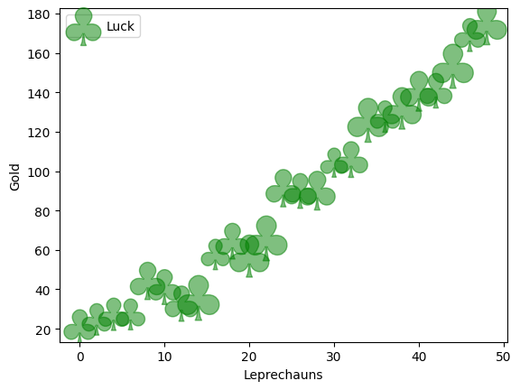

```python
import matplotlib.pyplot as plt
import numpy as np

# Fixing random state for reproducibility
np.random.seed(19680801)


x = np.arange(0.0, 50.0, 2.0)
y = x ** 1.3 + np.random.rand(*x.shape) * 30.0
s = np.random.rand(*x.shape) * 800 + 500

plt.scatter(x, y, s, c="g", alpha=0.5, marker=r'$\clubsuit$',
            label="Luck")
plt.xlabel("Leprechauns")
plt.ylabel("Gold")
plt.legend(loc='upper left')
plt.show()
```